# Multilevel Modelling Practical 6

## Instructions - start here!

**Exercise 1** involves the analysis of a longitudinal data set (full details below). **Exercise 2** considers long and wide data shapes, illustrated by the Oxford boys data set.

## Exercise 1

Let’s begin by loading the necessary packages and data:

```r
require(lme4)
require(ggplot2)
require(haven)
```

### Overview

The analysis starts by introducing the longitudinal data and some visual representations. This particular dataset was chosen for three primary reasons:

- It illustrates the basic notion of “time” in a slightly different context with the hope of a more intuitive understanding. The time variable is age and is continuous (contrary to most cases where it is presented as discrete) to showcase that what defines time is the repeated values within children, rather than a discrete definition and format.
- It binds well to the notion of covariance. When defined as a random intercept and random slope model, it has a fanning-out form that is distinct enough to produce a positive covariance, allowing for an intuitive explanation both illustratively and quantitatively of what the sign on a covariance implies.
- There is a non-linear relationship between the response and time, which presents us with an opportunity to showcase how to deal with it.

The practical continues by comparing the random intercept-only and full random effects models, again using `ggplot2`.

It then uses the full random effects model as the primary model to conduct diagnostic checks where non-linearity is discovered in the residuals plot and then countered using a squared age variable.

Some basic model assumptions are also tested using visual representations.

### Multilevel modelling with longitudinal data

```r
load("childweight.RData") # Insert directory
data <- childweight

weight <- data$weight
age <- data$age
birthw <- data$brthwt
girl <- data$girl
id.f <- as.factor(data$id)
```

$~$

Data summary and inspection

```r
head(data)
```

| id | age | weight | brthwt | girl |
| --- | --- | --- | --- | --- |
| 45 | 0.1368925 | 5.171 | 4140 | 0 |
| 45 | 0.6570842 | 10.860 | 4140 | 0 |
| 45 | 1.2183436 | 13.150 | 4140 | 0 |
| 45 | 1.4291581 | 13.200 | 4140 | 0 |
| 45 | 2.2724161 | 15.880 | 4140 | 0 |
| 258 | 0.1916496 | 5.300 | 3155 | 1 |

```r
summary(data)
```

```
##        id            age             weight           brthwt
##  Min.   :  45   Min.   :0.1150   Min.   : 3.100   Min.   :1575
##  1st Qu.:1271   1st Qu.:0.6461   1st Qu.: 7.008   1st Qu.:2807
##  Median :2351   Median :0.9966   Median : 9.071   Median :3120
##  Mean   :2491   Mean   :1.0806   Mean   : 8.837   Mean   :3106
##  3rd Qu.:3704   3rd Qu.:1.4709   3rd Qu.:10.890   3rd Qu.:3390
##  Max.   :4975   Max.   :2.5462   Max.   :17.200   Max.   :4270
##       girl
##  Min.   :0.0000
##  1st Qu.:0.0000
##  Median :0.0000
##  Mean   :0.4949
##  3rd Qu.:1.0000
##  Max.   :1.0000
```

Although in most cases of longitudinal analysis you will encounter discrete categorical time values (i.e. 1, 2, 3,…) in this setting, time is not discrete but continuous with differing values between children. This feature however, does not necessarily imply that any additional methodology is needed to handle this.

$~$

As previously, firstly plot the data by visualising the linear relationship.

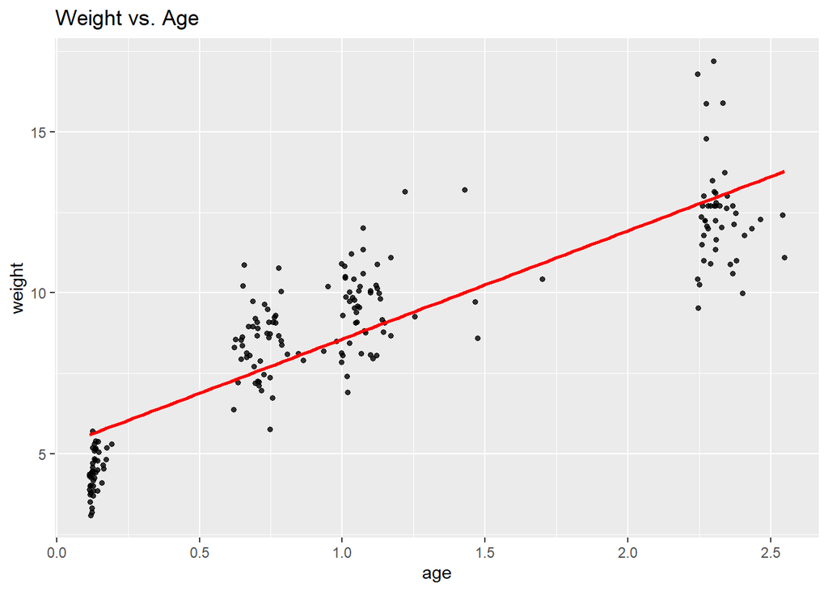

```r
ggplot(data  = data,
       aes(x = age,
           y = weight))+
  geom_point(size = 1.2,
             alpha = .8)+
  geom_smooth(method="lm",
              se=FALSE,
              col="Red")+
  labs(title = "Weight vs. Age")
```

$~$

Re-plot the relationship, this time inspecting group effects and the potential need for a multilevel model

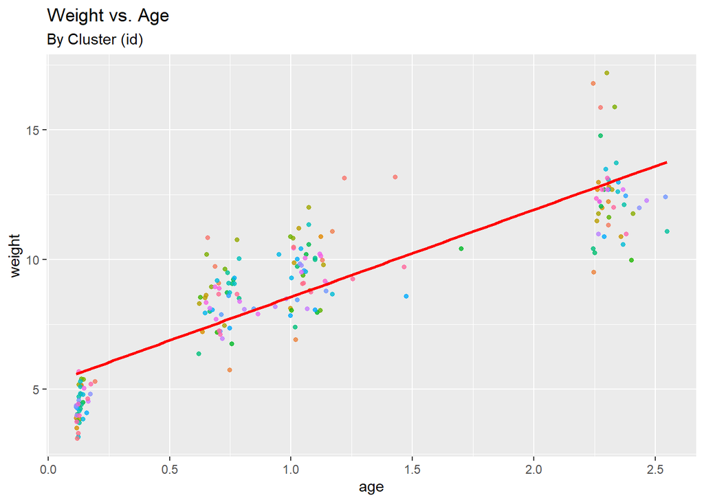

```r
ggplot(data  = data,
       aes(x = age,
           y = weight,
           col=id.f))+
  geom_point(size = 1.2,
             alpha = .8)+
  geom_smooth(method="lm",
              se=FALSE,
              col="Red")+
  theme(legend.position = "none")+
  labs(title = "Weight vs. Age",
       subtitle = "By Cluster (id)")
```

$~$

Let’s fit a multilevel model with random intercepts:

```r
lmodel <- lmer(weight ~ age  + girl + (1 | id), data=data)
summary(lmodel)
```

```
## Linear mixed model fit by REML ['lmerMod']
## Formula: weight ~ age + girl + (1 | id)
##    Data: data
##
## REML criterion at convergence: 694.5
##
## Scaled residuals:
##      Min       1Q   Median       3Q      Max
## -2.26782 -0.64129 -0.02437  0.72794  2.35999
##
## Random effects:
##  Groups   Name        Variance Std.Dev.
##  id       (Intercept) 0.5035   0.7095
##  Residual             1.5378   1.2401
## Number of obs: 198, groups:  id, 68
##
## Fixed effects:
##             Estimate Std. Error t value
## (Intercept)   5.5149     0.2152  25.630
## age           3.3888     0.1153  29.389
## girl         -0.7159     0.2499  -2.865
##
## Correlation of Fixed Effects:
##      (Intr) age
## age  -0.573
## girl -0.575 -0.006
```

$~$

Now extract and visualize the fitted values vs. the linear model:

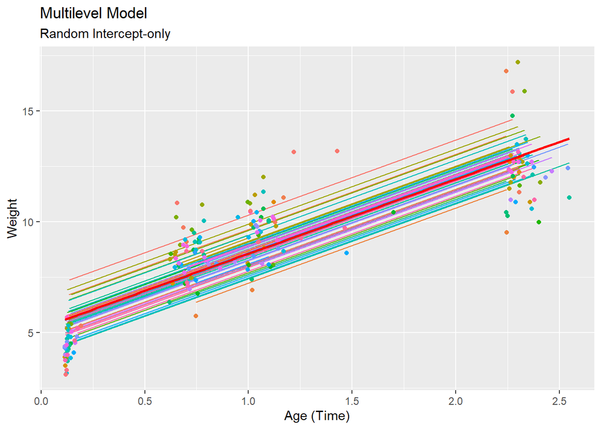

```r
data$pred1 <- predict(lmodel)

lmodel_int <- ggplot(data, aes(age,weight)) +
  geom_line(aes(y=pred1,group=id.f, col=id.f)) +
  geom_point(aes(age,weight,col=id.f)) +
  geom_smooth(method="lm",
              se=FALSE,
              col="Red") +
   ggtitle("Multilevel Model",
           subtitle="Random Intercept-only") +
  xlab("Age (Time)") +
  ylab("Weight") +
  theme(legend.position = "none")
lmodel_int
```

$~$ Multilevel model with both random intercepts and a random slope for time:

```r
lmodel2 <- lmer(weight ~ age + girl + (1 + age | id), data=data)
summary(lmodel2)
```

```
## Linear mixed model fit by REML ['lmerMod']
## Formula: weight ~ age + girl + (1 + age | id)
##    Data: data
##
## REML criterion at convergence: 684.1
##
## Scaled residuals:
##      Min       1Q   Median       3Q      Max
## -2.38416 -0.69583 -0.04232  0.73479  2.13691
##
## Random effects:
##  Groups   Name        Variance Std.Dev. Corr
##  id       (Intercept) 0.05702  0.2388
##           age         0.20709  0.4551   1.00
##  Residual             1.36994  1.1704
## Number of obs: 198, groups:  id, 68
##
## Fixed effects:
##             Estimate Std. Error t value
## (Intercept)   5.4293     0.1869  29.051
## age           3.4593     0.1264  27.362
## girl         -0.6354     0.2316  -2.744
##
## Correlation of Fixed Effects:
##      (Intr) age
## age  -0.488
## girl -0.612 -0.006
```

$~$

Visualize the fitted values:

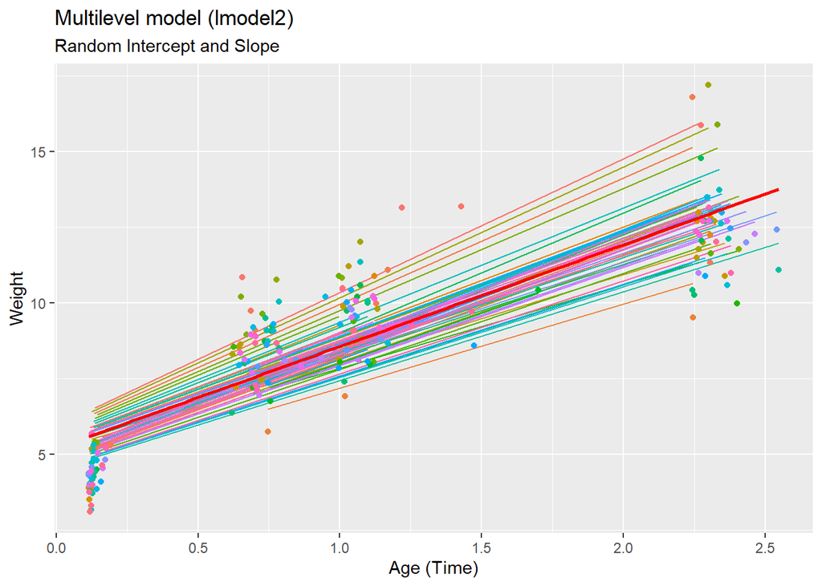

```r
data$pred2 <- predict(lmodel2)

lmodel_int_sl <- ggplot(data,aes(age,weight)) +
  geom_line(aes(y=pred2,group=id.f, col=id.f)) +
  geom_point(aes(age,weight, col=id.f)) +
  geom_smooth(method="lm",
              se=FALSE,
              col="Red")+
  ggtitle("Multilevel model (lmodel2)",
          subtitle="Random Intercept and Slope") +
  xlab("Age (Time)") +
  ylab("Weight")+
  theme(legend.position = "none")
lmodel_int_sl
```

$~$

Extract and inspect the variance-covariance matrix. Positive covariance re-affirms the fanning out pattern observed. The higher the predicted weight at baseline time (higher child intercept), the higher the weight will be as time passes (steeper intercept slope).

```r
Var_Cov_matrix <- as.data.frame(VarCorr(lmodel2))
Var_Cov_matrix
```

| grp | var1 | var2 | vcov | sdcor |
| --- | --- | --- | --- | --- |
| id | (Intercept) | NA | 0.05701865 | 0.2387858 |
| id | age | NA | 0.20708864 | 0.4550699 |
| id | (Intercept) | age | 0.10866423 | 0.9999999 |
| Residual | NA | NA | 1.36994491 | 1.1704465 |

$~$

Random intercept-only vs random intercept with random slope model visual comparison.

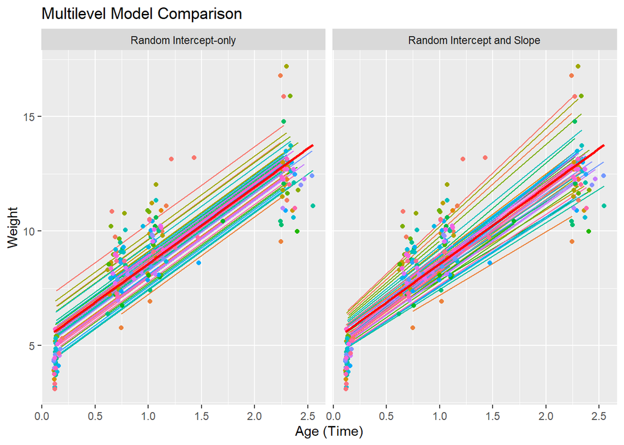

```r
vars <- c("id","age","weight")

data_pred1 <- cbind(data[,vars],setNames(data[,"pred1"], "pred"),group=1)
data_pred2 <- cbind(data[,vars],setNames(data[,"pred2"], "pred"),group=2)
data_comp <- rbind(data_pred1,data_pred2)

model_names <- c(`1`="Random Intercept-only",`2`="Random Intercept and Slope")

ggplot(data_comp, aes(age,weight)) +
  geom_line(aes(y=pred,group=as.factor(id),
                col=as.factor(id))) +
  geom_point(aes(age,weight,
                 col=as.factor(id))) +
  geom_smooth(method="lm",
              se=FALSE,
              col="Red")+
  facet_grid(~group,
             labeller = as_labeller(model_names)) +
  ggtitle("Multilevel Model Comparison") +
  xlab("Age (Time)") +
  ylab("Weight") +
  theme(legend.position = "none")
```

Given that the more complex model captures non-zero variance in random intercept and slope parameters, we will continue with it as our main model. $~$

So we will begin by inspecting the residuals. It is evident that the plot suggests an underlying non-linear structure.

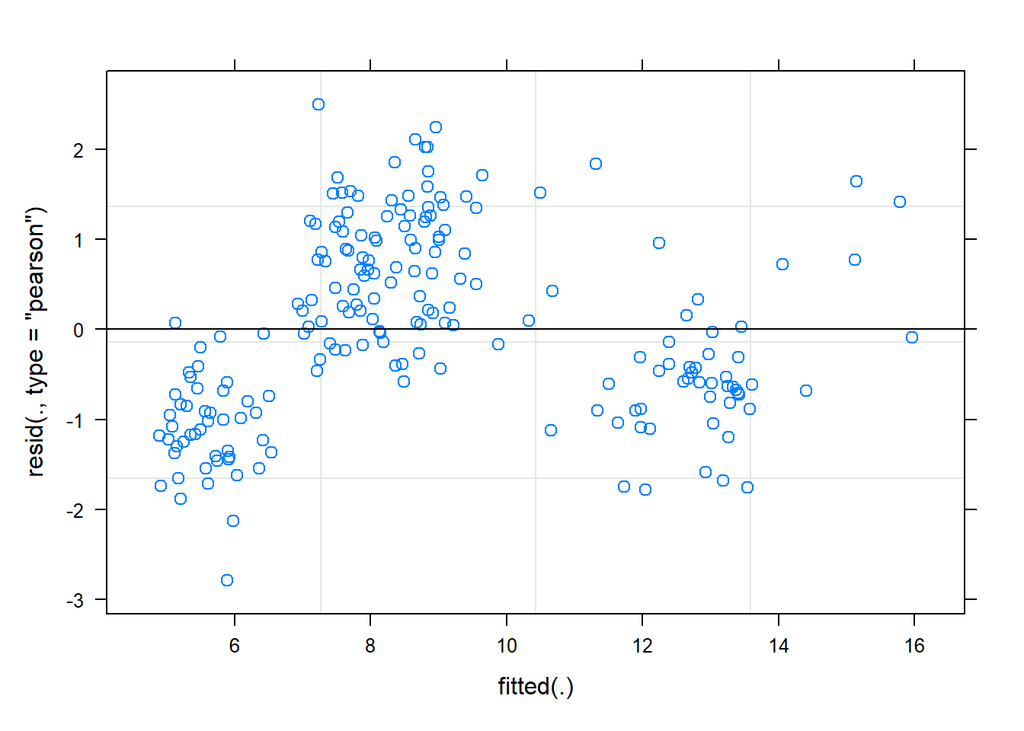

```r
plot(lmodel2)
```

$~$

In order to correct the non-linearity observed, perform multilevel modelling again, this time including a non-linear term for age. A significant squared age would imply that as age grows the effect of time will change.

```r
lmodel3 <- lmer(weight ~ age + c(age*age) + girl  + (1 + age | id), data=data)

summary(lmodel3)
```

```
## Linear mixed model fit by REML ['lmerMod']
## Formula: weight ~ age + c(age * age) + girl + (1 + age | id)
##    Data: data
##
## REML criterion at convergence: 518
##
## Scaled residuals:
##      Min       1Q   Median       3Q      Max
## -2.04189 -0.44260 -0.03241  0.41940  2.66968
##
## Random effects:
##  Groups   Name        Variance Std.Dev. Corr
##  id       (Intercept) 0.3781   0.6149
##           age         0.2681   0.5178   0.14
##  Residual             0.3296   0.5741
## Number of obs: 198, groups:  id, 68
##
## Fixed effects:
##              Estimate Std. Error t value
## (Intercept)   3.79550    0.16815  22.573
## age           7.69844    0.23985  32.096
## c(age * age) -1.65773    0.08859 -18.711
## girl         -0.59838    0.19997  -2.992
##
## Correlation of Fixed Effects:
##            (Intr) age    c(*ag)
## age        -0.543
## c(age*age)  0.502 -0.929
## girl       -0.588 -0.008  0.007
```

$~$

Inspecting again the residuals vs fitted values, it is evident that the non-linearity has been controlled for and residuals look much more acceptible.

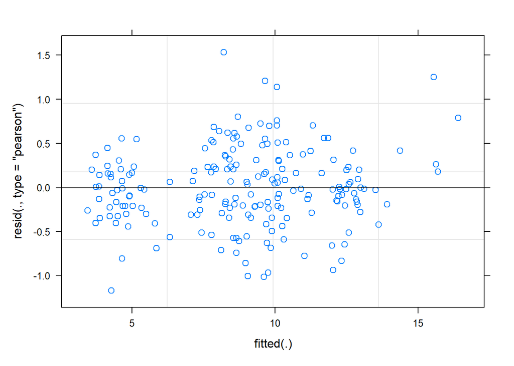

```r
plot(lmodel3)
```

$~$

We continue with inspection of model assumptions. i.e. normally distributed residuals and random effects. QQ Plots also look fairly acceptible (close to y=x line).

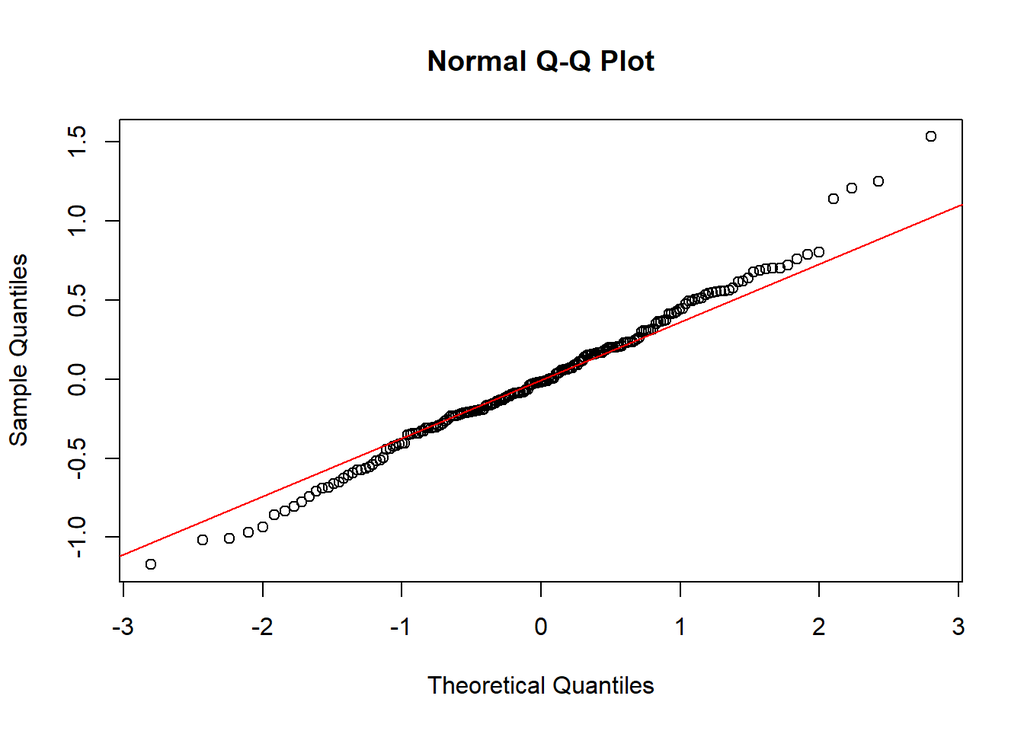

```r
qqnorm(resid(lmodel3))
qqline(resid(lmodel3),
       col = "red")
```

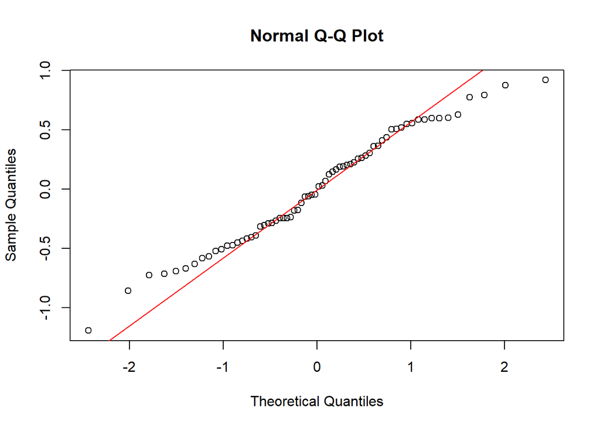

```r
qqnorm(ranef(lmodel3)$id[,1])
qqline(ranef(lmodel3)$id[,1],
       col = "red")
```

## Exercise 2 (Long and wide data shape)

Let’s return to the Oxboys data, discussed in the lecture, which is a built-in R data set:

```r
require(nlme)
data(Oxboys)
```

This data set was by default given in **long** format. But assume we wanted this data in **wide** format, for instance in order to carry out a multivariate analysis.

Let’s have a brief look at the data frame:

```r
head(Oxboys)
```

|  | Subject | age | height | Occasion |
| --- | --- | --- | --- | --- |
| 1 | 1 | -1.0000 | 140.5 | 1 |
| 2 | 1 | -0.7479 | 143.4 | 2 |
| 3 | 1 | -0.4630 | 144.8 | 3 |
| 4 | 1 | -0.1643 | 147.1 | 4 |
| 5 | 1 | -0.0027 | 147.7 | 5 |
| 6 | 1 | 0.2466 | 150.2 | 6 |

```r
dim(Oxboys)
```

```
## [1] 234   4
```

We see that there are two variables capturing the “time” component:

- the `age` variable
- the `Occasion` variable

There is a one-to-one relationship between these two variables, so for the purpose of creating a “wide” data frame, we can choose any of these. In this case, we have decided to drop `age`:

```r
Oxboys.wide <- reshape(Oxboys, direction="wide", idvar="Subject", timevar="Occasion", drop="age")
```

```r
head(Oxboys.wide)
```

|  | Subject | height.1 | height.2 | height.3 | height.4 | height.5 | height.6 | height.7 | height.8 | height.9 |
| --- | --- | --- | --- | --- | --- | --- | --- | --- | --- | --- |
| 1 | 1 | 140.5 | 143.4 | 144.8 | 147.10 | 147.70 | 150.2 | 151.7 | 153.3 | 155.8 |
| 10 | 2 | 136.9 | 139.1 | 140.1 | 142.60 | 143.20 | 144.0 | 145.8 | 146.8 | 148.3 |
| 19 | 3 | 150.0 | 152.1 | 153.9 | 155.80 | 156.00 | 156.9 | 157.4 | 159.1 | 160.6 |
| 28 | 4 | 155.7 | 158.7 | 160.6 | 163.30 | 164.40 | 167.3 | 170.7 | 172.0 | 174.8 |
| 37 | 5 | 145.8 | 147.3 | 148.7 | 149.78 | 150.22 | 152.5 | 154.8 | 156.4 | 158.7 |
| 46 | 6 | 142.4 | 143.8 | 145.2 | 146.30 | 147.10 | 148.1 | 148.9 | 149.1 | 151.0 |

This gives a multivariate data set of heights,

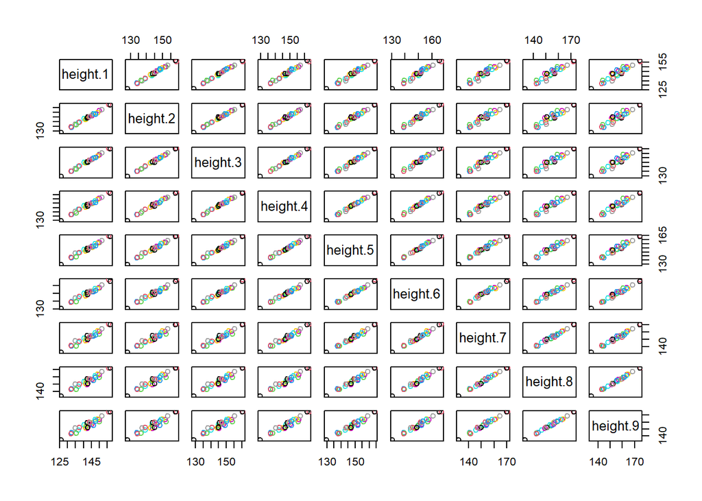

```r
plot(Oxboys.wide[,-1], col=Oxboys.wide$Subject)
```

which one could analyse using multivariate methods such as Principcal Component Analysis. We will not do this here, but consider the question how to re-transform the data back into a long data format:

```r
Oxboys.long<- reshape(Oxboys.wide, direction="long",
        idvar="Subject", varying=list(2:10),v.names="height" )
head(Oxboys.long)
```

|  | Subject | time | height |
| --- | --- | --- | --- |
| 1.1 | 1 | 1 | 140.5 |
| 2.1 | 2 | 1 | 136.9 |
| 3.1 | 3 | 1 | 150.0 |
| 4.1 | 4 | 1 | 155.7 |
| 5.1 | 5 | 1 | 145.8 |
| 6.1 | 6 | 1 | 142.4 |

**TASK:** Convince yourself that the `Oxboys.long` data frame is equivalent to the original `Oxboys` frame.